# Assignment 3

Sungjoo Cho, Catherine (Kate) Lamoreaux

2023-10-24

## Our GitHub Repository

https://github.com/katelmrx/cho-lamoreaux-a1

### Packages

```r
library(xml2)
library(rvest)
library(tidyverse)
library(robotstxt)
library(janeaustenr)
library(dplyr)
library(stringr)
library(tidytext)
library(ggplot2)
library(stringi)
```

## Wikipedia

```r
# Review whether we are allowed to do web scraping
paths_allowed("https://en.wikipedia.org/wiki/Grand_Boulevard,_Chicago")
```

```
##
 en.wikipedia.org
```

```
## [1] TRUE
```

Because the result is true, we are allowed to scrape from Wikipedia.

```r
# # Reading in the html page as R object url
url_gb <- read_html("https://en.wikipedia.org/wiki/Grand_Boulevard,_Chicago")
str(url_gb)
```

```
## List of 2
##  $ node:<externalptr>
##  $ doc :<externalptr>
##  - attr(*, "class")= chr [1:2] "xml_document" "xml_node"
```

## 1. Grab the html elements

As a first step, read in the html page as an R object. Extract the tables from this object (using the `rvest` package) and save the result as a new object. Follow the instructions if there is an error. Use `str()` on this new object. It should be a list. Try to find the position of the “Historical population” in this list since we need it in the next step.

```r
# Extracting the tables from object url_gb (using the `rvest` package)
nds <- html_elements(url_gb, xpath = '//table')
```

```r
# Using `str()` on new object nds, which is a list
str(nds)
```

```
## List of 7
##  $ :List of 2
##   ..$ node:<externalptr>
##   ..$ doc :<externalptr>
##   ..- attr(*, "class")= chr "xml_node"
##  $ :List of 2
##   ..$ node:<externalptr>
##   ..$ doc :<externalptr>
##   ..- attr(*, "class")= chr "xml_node"
##  $ :List of 2
##   ..$ node:<externalptr>
##   ..$ doc :<externalptr>
##   ..- attr(*, "class")= chr "xml_node"
##  $ :List of 2
##   ..$ node:<externalptr>
##   ..$ doc :<externalptr>
##   ..- attr(*, "class")= chr "xml_node"
##  $ :List of 2
##   ..$ node:<externalptr>
##   ..$ doc :<externalptr>
##   ..- attr(*, "class")= chr "xml_node"
##  $ :List of 2
##   ..$ node:<externalptr>
##   ..$ doc :<externalptr>
##   ..- attr(*, "class")= chr "xml_node"
##  $ :List of 2
##   ..$ node:<externalptr>
##   ..$ doc :<externalptr>
##   ..- attr(*, "class")= chr "xml_node"
##  - attr(*, "class")= chr "xml_nodeset"
```

```r
# Using html_table() on the nds object to search for the
# "Historical population" table within this list
table_details <- html_table(nds)
head(table_details)
```

```
## [[1]]
## # A tibble: 26 × 2
##    `Grand Boulevard`                                           `Grand Boulevard`
##    <chr>                                                       <chr>
##  1 Community area                                              "Community area"
##  2 Community Area 38 - Grand Boulevard                         "Community Area …
##  3 The Harold Washington Cultural Center                       "The Harold Wash…
##  4 Location within the city of Chicago                         "Location within…
##  5 Coordinates: .mw-parser-output .geo-default,.mw-parser-out… "Coordinates: .m…
##  6 Country                                                     "United States"
##  7 State                                                       "Illinois"
##  8 County                                                      "Cook"
##  9 City                                                        "Chicago"
## 10 Neighborhoods                                               "List\nBronzevil…
## # ℹ 16 more rows
##
## [[2]]
## # A tibble: 11 × 4
##    Census Pop.    .mw-parser-output .sr-only{border:0;clip:rect(0,0,0,0)…¹ `%±`
##    <chr>  <chr>   <chr>                                                    <chr>
##  1 1930   87,005  ""                                                       —
##  2 1940   103,256 ""                                                       18.7%
##  3 1950   114,557 ""                                                       10.9%
##  4 1960   80,036  ""                                                       −30.…
##  5 1970   80,166  ""                                                       0.2%
##  6 1980   53,741  ""                                                       −33.…
##  7 1990   35,897  ""                                                       −33.…
##  8 2000   28,006  ""                                                       −22.…
##  9 2010   21,929  ""                                                       −21.…
## 10 2020   24,589  ""                                                       12.1%
## 11 [3][1] [3][1]  "[3][1]"                                                 [3][…
## # ℹ abbreviated name:
## #   ¹`.mw-parser-output .sr-only{border:0;clip:rect(0,0,0,0);clip-path:polygon(0px 0px,0px 0px,0px 0px);height:1px;margin:-1px;overflow:hidden;padding:0;position:absolute;width:1px;white-space:nowrap}Note`
##
## [[3]]
## # A tibble: 6 × 17
##   Places adjacent to Gran…¹ Places adjacent to G…² ``    ``    ``    ``    ``
##   <chr>                     <chr>                  <chr> <chr> <chr> <lgl> <lgl>
## 1 "Armour Square, Chicago\… "Armour Square, Chica… "Arm… Doug… Oakl… NA    NA
## 2 "Armour Square, Chicago"  "Douglas, Chicago"     "Oak… <NA>  <NA>  NA    NA
```

[output cut: 28 more lines]

```
## 6 South                                                   "Armour Square\nDougl…
## 7 Southwest                                               "Garfield Ridge\nArch…
## 8 Far Southwest                                           "Ashburn\nAuburn Gres…
## 9 Far Southeast                                           "Chatham\nAvalon Park…
## # ℹ abbreviated names:
## #   ¹`.mw-parser-output .navbar{display:inline;font-size:88%;font-weight:normal}.mw-parser-output .navbar-collapse{float:left;text-align:left}.mw-parser-output .navbar-boxtext{word-spacing:0}.mw-parser-output .navbar ul{display:inline-block;white-space:nowrap;line-height:inherit}.mw-parser-output…
## #   ²`.mw-parser-output .navbar{display:inline;font-size:88%;font-weight:normal}.mw-parser-output .navbar-collapse{float:left;text-align:left}.mw-parser-output .navbar-boxtext{word-spacing:0}.mw-parser-output .navbar ul{display:inline-block;white-space:nowrap;line-height:inherit}.mw-parser-output…
##
## [[6]]
## # A tibble: 2 × 2
##   `vteNeighborhoods in Chicago`                         vteNeighborhoods in Ch…¹
##   <chr>                                                 <chr>
## 1 Recognized by the City of Chicago                     "Albany Park\nAndersonv…
## 2 Other districts and areas recognized by the community "Altgeld Gardens\nArmou…
## # ℹ abbreviated name: ¹`vteNeighborhoods in Chicago`
```

The “Historical population” table is in [[2]] of the table_details list.

Extract the “Historical population” table from the list and save it as another object. You can use subsetting via `[[…]]` to extract pieces from a list. Print the result.

```r
# Extracting the "Historical population" table from list table_details
# Saving this as object pop
pop <- table_details[[2]]

# Printing pop
print(pop)
```

```
## # A tibble: 11 × 4
##    Census Pop.    .mw-parser-output .sr-only{border:0;clip:rect(0,0,0,0)…¹ `%±`
##    <chr>  <chr>   <chr>                                                    <chr>
##  1 1930   87,005  ""                                                       —
##  2 1940   103,256 ""                                                       18.7%
##  3 1950   114,557 ""                                                       10.9%
##  4 1960   80,036  ""                                                       −30.…
##  5 1970   80,166  ""                                                       0.2%
##  6 1980   53,741  ""                                                       −33.…
##  7 1990   35,897  ""                                                       −33.…
##  8 2000   28,006  ""                                                       −22.…
##  9 2010   21,929  ""                                                       −21.…
## 10 2020   24,589  ""                                                       12.1%
## 11 [3][1] [3][1]  "[3][1]"                                                 [3][…
## # ℹ abbreviated name:
## #   ¹`.mw-parser-output .sr-only{border:0;clip:rect(0,0,0,0);clip-path:polygon(0px 0px,0px 0px,0px 0px);height:1px;margin:-1px;overflow:hidden;padding:0;position:absolute;width:1px;white-space:nowrap}Note`
```

```r
# Keeping only rows and columns with actual values
pop <- pop[1:10, -3]
pop
```

| Census | Pop. | %± |
| --- | --- | --- |
| 1930 | 87,005 | — |
| 1940 | 103,256 | 18.7% |
| 1950 | 114,557 | 10.9% |
| 1960 | 80,036 | −30.1% |
| 1970 | 80,166 | 0.2% |
| 1980 | 53,741 | −33.0% |
| 1990 | 35,897 | −33.2% |
| 2000 | 28,006 | −22.0% |
| 2010 | 21,929 | −21.7% |
| 2020 | 24,589 | 12.1% |

## 2. Expanding to More Pages

That’s it for this page. However, we may want to repeat this process for other community areas. The Wikipedia page [https://en.wikipedia.org/wiki/Grand_Boulevard,\_Chicago](https://en.wikipedia.org/wiki/Grand_Boulevard,_Chicago) has a section on “Places adjacent to Grand Boulevard, Chicago” at the bottom. Can you find the corresponding table in the list of tables that you created earlier? Extract this table as a new object.

The “Places adjacent to Grand Boulevard, Chicago” table is in [4] of the table_details list.

```r
# Extracting "Places adjacent to Grand Boulevard, Chicago" table
# Assigning this table to object gb_adj
(gb_adj <- table_details[[4]])
```

| X1 | X2 | X3 |
| --- | --- | --- |
| Armour Square, Chicago | Douglas, Chicago | Oakland, Chicago |
| Fuller Park, Chicago | Grand Boulevard, Chicago | Kenwood, Chicago |
|  | Washington Park, Chicago | Hyde Park, Chicago |

Then, grab the community areas east of Grand Boulevard and save them as a character vector. Print the result.

```r
# Saving communities east of Grand Boulevard and removing blank characters from
# the character string, named east_gb
(east_gb <- gb_adj$X3 %>% stri_remove_empty_na())
```

```
## [1] "Oakland, Chicago"   "Kenwood, Chicago"   "Hyde Park, Chicago"
```

We want to use this list to create a loop that extracts the population tables from the Wikipedia pages of these places. To make this work and build valid urls, we need to replace empty spaces in the character vector with underscores. This can be done with `gsub()`, or by hand. The resulting vector should look like this: “Oakland,_Chicago” “Kenwood,_Chicago” “Hyde_Park,_Chicago”

```r
# Using gsub to replace the empty spaces of the character vector east_gb
# with underscores
(east_gb <- gsub(" ", "_", east_gb))
```

```
## [1] "Oakland,_Chicago"   "Kenwood,_Chicago"   "Hyde_Park,_Chicago"
```

To prepare the loop, we also want to copy our `pop` table and rename it as `pops`. In the loop, we append this table by adding columns from the other community areas.

```r
pops <- pop
```

Build a small loop to test whether you can build valid urls using the vector of places and pasting each element of it after `https://en.wikipedia.org/wiki/` in a for loop. Calling `url` shows the last url of this loop, which should be `https://en.wikipedia.org/wiki/Hyde_Park,_Chicago`.

```r
# Building a small test loop
for(i in east_gb) {
   url <- paste0("https://en.wikipedia.org/wiki/",i, sep = "")
   src <- read_html(url)
  print(url)   }
```

```
## [1] "https://en.wikipedia.org/wiki/Oakland,_Chicago"
## [1] "https://en.wikipedia.org/wiki/Kenwood,_Chicago"
## [1] "https://en.wikipedia.org/wiki/Hyde_Park,_Chicago"
```

```r
url
```

```
## [1] "https://en.wikipedia.org/wiki/Hyde_Park,_Chicago"
```

Finally, extend the loop and add the code that is needed to grab the population tables from each page. Add columns to the original table `pops` using `cbind()`.

```r
# Extending the loop
for(i in east_gb) {
   url <- paste0("https://en.wikipedia.org/wiki/",i)
   src <- read_html(url)
  print(url)

# Extracting the tables from object src (using the `rvest` package)
    nds <- html_elements(src, xpath = '//table')

# Using html_table() on the nds object
    table_details <- html_table(nds)

# Extracting the "Historical population" table from list table_details
# Saving this as object pop
  pop <- table_details[[2]]

# Keeping only rows and columns with actual values
  pop <- pop[1:10, -3]

pops <- cbind(pops, pop)

}
```

```
## [1] "https://en.wikipedia.org/wiki/Oakland,_Chicago"
## [1] "https://en.wikipedia.org/wiki/Kenwood,_Chicago"
## [1] "https://en.wikipedia.org/wiki/Hyde_Park,_Chicago"
```

```r
pops
```

| Census | Pop. | %± | Census | Pop. | %± | Census | Pop. | %± | Census | Pop. | %± |
| --- | --- | --- | --- | --- | --- | --- | --- | --- | --- | --- | --- |
| 1930 | 87,005 | — | 1930 | 14,962 | — | 1930 | 26,942 | — | 1930 | 48,017 | — |
| 1940 | 103,256 | 18.7% | 1940 | 14,500 | −3.1% | 1940 | 29,611 | 9.9% | 1940 | 50,550 | 5.3% |
| 1950 | 114,557 | 10.9% | 1950 | 24,464 | 68.7% | 1950 | 35,705 | 20.6% | 1950 | 55,206 | 9.2% |
| 1960 | 80,036 | −30.1% | 1960 | 24,378 | −0.4% | 1960 | 41,533 | 16.3% | 1960 | 45,577 | −17.4% |
| 1970 | 80,166 | 0.2% | 1970 | 18,291 | −25.0% | 1970 | 26,890 | −35.3% | 1970 | 33,531 | −26.4% |
| 1980 | 53,741 | −33.0% | 1980 | 16,748 | −8.4% | 1980 | 21,974 | −18.3% | 1980 | 31,198 | −7.0% |
| 1990 | 35,897 | −33.2% | 1990 | 8,197 | −51.1% | 1990 | 18,178 | −17.3% | 1990 | 28,630 | −8.2% |
| 2000 | 28,006 | −22.0% | 2000 | 6,110 | −25.5% | 2000 | 18,363 | 1.0% | 2000 | 29,920 | 4.5% |
| 2010 | 21,929 | −21.7% | 2010 | 5,918 | −3.1% | 2010 | 17,841 | −2.8% | 2010 | 25,681 | −14.2% |
| 2020 | 24,589 | 12.1% | 2020 | 6,799 | 14.9% | 2020 | 19,116 | 7.1% | 2020 | 29,456 | 14.7% |

```r
str(pops)
```

```
## 'data.frame':    10 obs. of  12 variables:
##  $ Census: chr  "1930" "1940" "1950" "1960" ...
##  $ Pop.  : chr  "87,005" "103,256" "114,557" "80,036" ...
##  $ %±    : chr  "—" "18.7%" "10.9%" "−30.1%" ...
##  $ Census: chr  "1930" "1940" "1950" "1960" ...
##  $ Pop.  : chr  "14,962" "14,500" "24,464" "24,378" ...
##  $ %±    : chr  "—" "−3.1%" "68.7%" "−0.4%" ...
##  $ Census: chr  "1930" "1940" "1950" "1960" ...
##  $ Pop.  : chr  "26,942" "29,611" "35,705" "41,533" ...
##  $ %±    : chr  "—" "9.9%" "20.6%" "16.3%" ...
##  $ Census: chr  "1930" "1940" "1950" "1960" ...
##  $ Pop.  : chr  "48,017" "50,550" "55,206" "45,577" ...
##  $ %±    : chr  "—" "5.3%" "9.2%" "−17.4%" ...
```

## 3. Scraping and Analyzing Text Data

Suppose we wanted to take the actual text from the Wikipedia pages instead of just the information in the table. Our goal in this section is to extract the text from the body of the pages, then do some basic text cleaning and analysis.

First, scrape just the text without any of the information in the margins or headers. For example, for “Grand Boulevard”, the text should start with, “**Grand Boulevard** on the [South Side](https://en.wikipedia.org/wiki/South_Side,_Chicago) of Chicago, Illinois, is one of the …”.

### (1) Creating a corpus

```r
# Extracting desired text elements from webpage
nds_text <- html_elements(url_gb, xpath = "//p")
str(nds_text)
```

```
## List of 8
##  $ :List of 2
##   ..$ node:<externalptr>
##   ..$ doc :<externalptr>
##   ..- attr(*, "class")= chr "xml_node"
##  $ :List of 2
##   ..$ node:<externalptr>
##   ..$ doc :<externalptr>
##   ..- attr(*, "class")= chr "xml_node"
##  $ :List of 2
##   ..$ node:<externalptr>
##   ..$ doc :<externalptr>
##   ..- attr(*, "class")= chr "xml_node"
##  $ :List of 2
##   ..$ node:<externalptr>
##   ..$ doc :<externalptr>
##   ..- attr(*, "class")= chr "xml_node"
##  $ :List of 2
##   ..$ node:<externalptr>
##   ..$ doc :<externalptr>
##   ..- attr(*, "class")= chr "xml_node"
##  $ :List of 2
##   ..$ node:<externalptr>
##   ..$ doc :<externalptr>
##   ..- attr(*, "class")= chr "xml_node"
##  $ :List of 2
##   ..$ node:<externalptr>
##   ..$ doc :<externalptr>
##   ..- attr(*, "class")= chr "xml_node"
##  $ :List of 2
##   ..$ node:<externalptr>
##   ..$ doc :<externalptr>
##   ..- attr(*, "class")= chr "xml_node"
##  - attr(*, "class")= chr "xml_nodeset"
```

```r
# Reading html text
(description <- html_text(nds_text))
```

```
## [1] "\n"
## [2] "Grand Boulevard on the South Side of Chicago, Illinois, is one of the city's Community Areas. The boulevard from which it takes its name is now Martin Luther King Jr. Drive. The area is bounded by 39th to the north, 51st Street to the south, Cottage Grove Avenue to the east, and the Chicago,…
## [3] "This is one of the two community areas that encompass the Bronzeville neighborhood, with the other being Douglas. Grand Boulevard also includes the Washington Park Court District neighborhood that was declared a Chicago Landmark on October 2, 1991.[2]"
## [4] "The Harold Washington Cultural Center is one of its newer and more famous buildings. It arose on the site that from the 1920s through the 1970s housed a famous center of African American cultural life, the Regal Theater. Among the other notable properties in this neighborhood are the Daniel …
## [5] "According to a 2018 US Census American Community Survey, there were 22,784 people and 10,383 households in Grand Boulevard.[1] The racial makeup of the area was 92.56% African American, 2.70% White, 0.70% Asian, and 2.26% from other races. Hispanic or Latino residents of any race were 1.77% …
## [6] "Grand Boulevard is part of City of Chicago School District #299 and City Colleges of Chicago District #508. The nearest City Colleges campus was Kennedy–King College in Englewood. A high school diploma had been earned by 85.5% of Grand Boulevard residents and a bachelor's degree or greater h…
## [7] "The Chicago Transit Authority operates the Chicago \"L\" system in the Grand Boulevard community area. The Green Line provides rapid transit at four stations: Indiana, 43rd Street, 47th Street and 51st Street stations.\n"
## [8] "The Grand Boulevard community area has supported the Democratic Party in the past two presidential elections by overwhelming margins. In the 2016 presidential election, Grand Boulevard cast 10,081 votes for Hillary Clinton and cast 171 votes for Donald Trump.[4] In the 2012 presidential elec…
```

```r
# Making sure all of the text is in one block
(description <- description %>% paste(collapse = ' '))
```

```
## [1] "\n Grand Boulevard on the South Side of Chicago, Illinois, is one of the city's Community Areas. The boulevard from which it takes its name is now Martin Luther King Jr. Drive. The area is bounded by 39th to the north, 51st Street to the south, Cottage Grove Avenue to the east, and the Chica…
```

### (2) Grab the descriptions of the various communities areas using for loop

Using a similar loop as in the last section, grab the descriptions of the various communities areas. Make a tibble with two columns: the name of the location and the text describing the location.

```r
# Making a copy of description to prepare the loop
descriptions <- description
```

```r
# Using a similar loop to grab descriptions of the eastern community areas
for(i in east_gb) {
   url <- paste0("https://en.wikipedia.org/wiki/",i)
   src <- read_html(url)
  print(url)

 # Text source
  nds_text_src <- html_elements(src, xpath = "//p")

# Extracting the tables from object nds_text_src
description <- html_text(nds_text_src)

# Make sure all of the text is in one block
description <- description %>% paste(collapse = ' ')

descriptions <- rbind(descriptions, description)
}
```

```
## [1] "https://en.wikipedia.org/wiki/Oakland,_Chicago"
## [1] "https://en.wikipedia.org/wiki/Kenwood,_Chicago"
## [1] "https://en.wikipedia.org/wiki/Hyde_Park,_Chicago"
```

```r
# Viewing output
str(descriptions)
```

```
##  chr [1:4, 1] "\n Grand Boulevard on the South Side of Chicago, Illinois, is one of the city's Community Areas. The boulevard "| __truncated__ ...
##  - attr(*, "dimnames")=List of 2
##   ..$ : chr [1:4] "descriptions" "description" "description" "description"
##   ..$ : NULL
```

```r
# Making a tibble with two columns: the name of the location and
# the text describing the location.
descriptions_df <- as.tibble(descriptions)
chi_neighborhood <- data.frame(
  "neighborhood" = c("Grand Boulevard","Oakland", "Kenwood","Hyde Park"),
  "description_text" = descriptions_df$V1)

chi_neighborhood <- as.tibble(chi_neighborhood)
head(chi_neighborhood)
```

| neighborhood | description_text |
| --- | --- |
| Grand Boulevard | \n Grand Boulevard on the South Side of Chicago, Illinois, is one of the city's Community Areas. The boulevard from which it takes its name is now Martin Luther King Jr. Drive. The area is bounded by … |
| Oakland | Oakland, located on the South Side of Chicago, Illinois, USA, is one of 77 officially designated Chicago community areas. Bordered by 35th and 43rd Streets, Cottage Grove Avenue and Lake Shore Drive, … |
| Kenwood | \n Kenwood, one of Chicago's 77 community areas, is on the shore of Lake Michigan on the South Side of the city. Its boundaries are 43rd Street, 51st Street, Cottage Grove Avenue, and the lake. Kenwoo… |
| Hyde Park | \n Hyde Park is the 41st of the 77 community areas of Chicago. It is located on the South Side, near the shore of Lake Michigan 7 miles (11 km) south of the Loop. \n Hyde Park's official boundaries ar… |

### (3) Create tokens using unnest tokens. Make sure the data is in one token per row format. Remove any stop words within the data. What are the most common words used overall?

```r
# Creating tokens using unnest_tokens
chi_tokens <- chi_neighborhood %>%
  unnest_tokens(word, description_text)

# Making sure the data is in one token per row format
head(chi_tokens)
```

| neighborhood | word |
| --- | --- |
| Grand Boulevard | grand |
| Grand Boulevard | boulevard |
| Grand Boulevard | on |
| Grand Boulevard | the |
| Grand Boulevard | south |
| Grand Boulevard | side |

```r
# Removing stop words
data("stop_words")
chi_tokens <- chi_tokens %>%
  anti_join(stop_words)
head(chi_tokens)
```

| neighborhood | word |
| --- | --- |
| Grand Boulevard | grand |
| Grand Boulevard | boulevard |
| Grand Boulevard | south |
| Grand Boulevard | chicago |
| Grand Boulevard | illinois |
| Grand Boulevard | city's |

```r
# Count the most common words used overall
token_count <- chi_tokens %>%
  count(word, sort = TRUE)
head(token_count)
```

| word | n |
| --- | --- |
| park | 89 |
| hyde | 75 |
| chicago | 57 |
| street | 44 |
| kenwood | 38 |
| community | 28 |

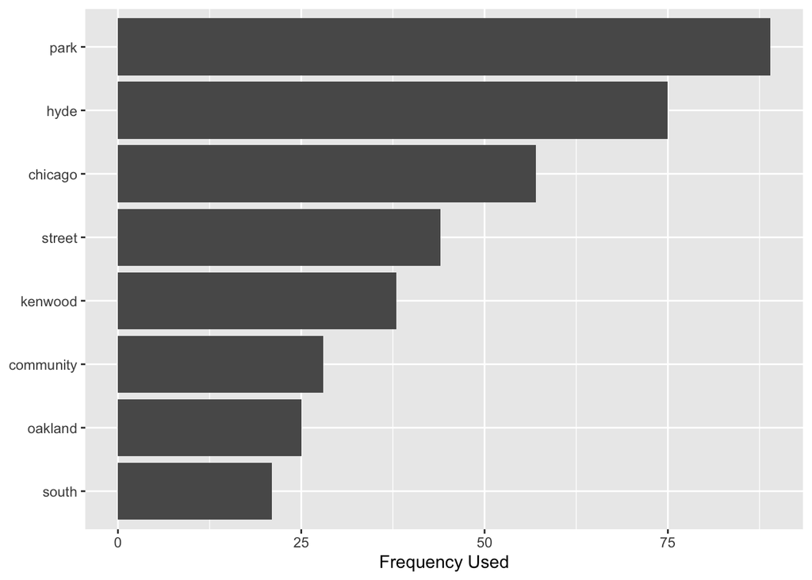

```r
# Plot the most common words used overall
token_count %>%
  filter(n > 20) %>%
  mutate(word = reorder(word, n)) %>%
  ggplot(aes(n, word)) +
  geom_col() +
  labs(x = "Frequency Used", y = NULL)
```

Upon removing stop words, the most common words used overall are: “park” (n=89), “hyde” (n=75), and “chicago” (n=57).

### (4) Plot the most common words within each location. What are some of the similarities between the locations? What are some of the differences?

```r
(grouped_tokens <- chi_tokens %>%
  group_by(neighborhood)%>%
  count(word, sort = TRUE))
```

| neighborhood | word | n |
| --- | --- | --- |
| Hyde Park | park | 77 |
| Hyde Park | hyde | 69 |
| Hyde Park | chicago | 34 |
| Hyde Park | street | 28 |
| Kenwood | kenwood | 25 |
| Oakland | oakland | 25 |
| Hyde Park | university | 18 |
| Hyde Park | house | 15 |
| Hyde Park | south | 13 |
| Hyde Park | 55th | 11 |

[output cut: 1488 more lines]

```r
# plot for the most common words within Grand Boulevard
token_Grand_Boulevard <- grouped_tokens %>%
  filter(neighborhood == "Grand Boulevard") %>%
  slice(1:6) %>%
  mutate(word = reorder(word, n)) %>%
  ggplot(aes(n, word)) +
  geom_col(fill="gold") +
  labs(title = "Grand Boulevard Description", x = "Frequency Used", y = NULL)

# plot for the most common words within Oakland
token_Oakland <- grouped_tokens %>%
  filter(neighborhood == "Oakland") %>%
  slice(1:6) %>%
  mutate(word = reorder(word, n)) %>%
  ggplot(aes(n, word)) +
  geom_col(fill="orchid") +
  labs(title = "Oakland Description", x = "Frequency Used", y = NULL)

# plot for the most common words within Kenwood
token_Kenwood <- grouped_tokens %>%
  filter(neighborhood == "Kenwood") %>%
  slice(1:6) %>%
  mutate(word = reorder(word, n)) %>%
  ggplot(aes(n, word)) +
  geom_col(fill="royalblue") +
  labs(title = "Kenwood Description", x = "Frequency Used", y = NULL)

# plot for the most common words within Hyde_Park
token_Hyde_Park <- grouped_tokens %>%
  filter(neighborhood == "Hyde Park") %>%
  slice(1:6) %>%
  mutate(word = reorder(word, n)) %>%
  ggplot(aes(n, word)) +
  geom_col(fill="seagreen") +
  labs(title = "Hyde Park Description", x = "Frequency Used", y = NULL)
```

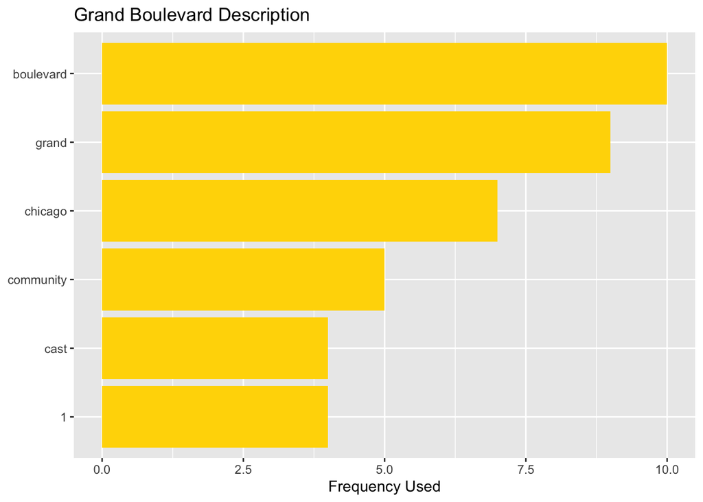

```r
# plots
token_Grand_Boulevard
```

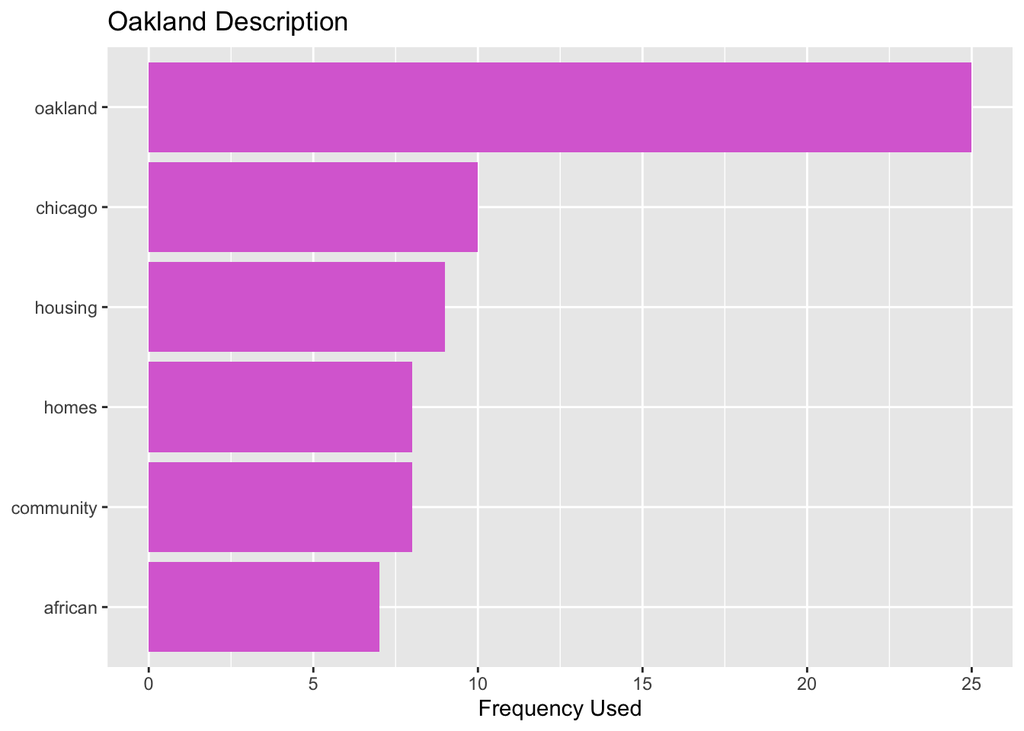

```r
token_Oakland
```

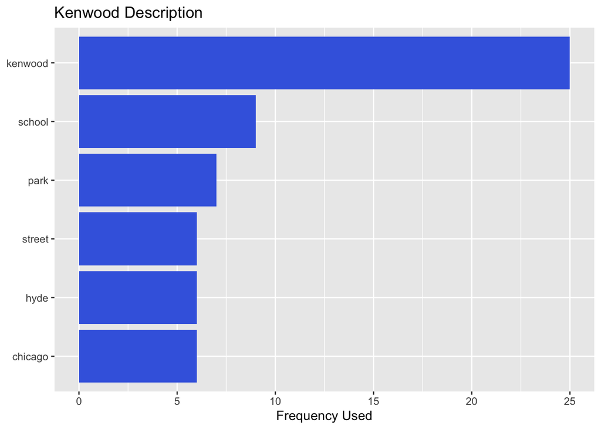

```r
token_Kenwood
```

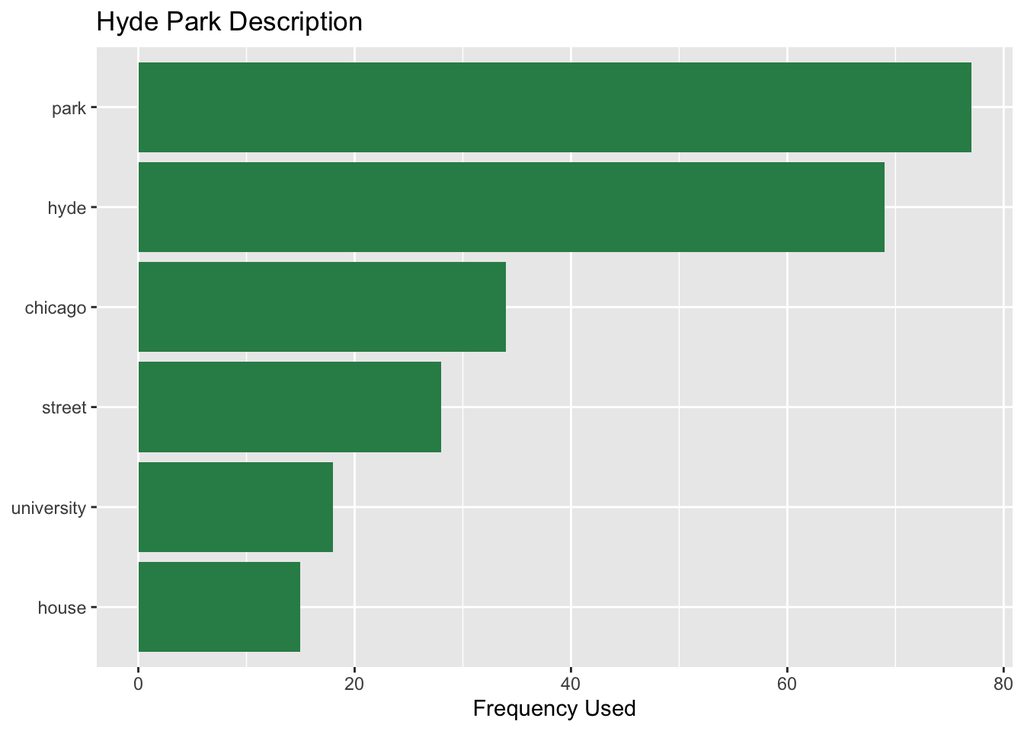

```r
token_Hyde_Park
```

The most common words used in the Grand Boulevard description are: “boulevard”, “grand”, and “chicago”.

The most common words used in the Oakland description are: “oakland”, “chicago”, and “housing”.

The most common words used in the Kenwood description are: “kenwood”, “school”, and “park”.

The most common words used in the Hyde Park description are: “park”, “hyde”, and “chicago”.

All of the neighborhood descriptions had parts of each respective neighborhood name as some of their top used words. Unsurprisingly, “chicago” was in the top 6 words used in all of the neighborhoods. Neighborhoods also featured words that reflected what was in them. For instance the Hyde Park neighborhood description had “university” as its fifth most frequently used word, which makes sense as Hyde Park is home to the University of Chicago.